# Analytics Edge: Unit 4 - An Introduction to Trees

Sulman Khan

October 26, 2018

## Judge, Jury, and Classifier

### The American Legal System

- The legal system of the United States operates at the state level and at the federal level
- Federal courts hear cases beyond the scope of state law
- Federal courts are divided into:
  - District Courts
    - Makes initial decision
  - Circuit Courts
    - Hears appeals from the district courts
  - Supreme Court
    - Highest level - makes final decision

### The Supreme Court of the United States

- Consists of nine judges (“justices”), appointed by the President
  - Justices are distinguished judges, professors of law, state and federal attorneys
- The Supreme Court of the United States (SCOTUS) decides on most difficult and controversial cases
  - Often involve interpretation of the Constitution
  - Significant social, political and economic consequences

### Notable SCOTUS Decisions

- Wickard v. Filbum (1942)
  - Congress allowed to intervene in industrial/economic activity
- Roe v. Wade (1973)
  - Legalized abortion
- Bush v. Gore (2000)
  - Decided outcome of presidential election
- National Federation of Independent Business v. Sebelius (2012)
  - Patient Protection and Affordable Care Act (“ObamaCare”) upheld the requirement that individuals must buy health insurance

### Predicting Supreme Court Cases

- Legal academics and political scientists regularly make predictions of SCOTUS decisions from detailed studies of cases and individual justices
- In 2002, Andrew Martin, a professor of political science at Washington University in St. Louis, decided to instead predict decisions using a statistical model built from data
- Together with his colleagues, he decided to test this model against a panel of experts
- Martin used a method called Classification and Regression Trees (CART)
- Why not logistic regression?
  - Logistic regression models are generally not *intepretable*
  - Model coefficients indicate importance and relative effect of variables, but do not give a simple explanation of how decision is made

### Data

- Cases from 1994 through 2001
- In this period, same nine justices presided SCOTUS
  - Breyer, Ginsburg, Kennedy, O’Connor, Rehnquist (Chief Justice), Scalia, Souter, Stevens, Thomas
  - Rare data set - longest period of time with the same set of justices in over 180 years
- We will focus on predicting Justice Stevens’ decisions
  - Started out moderate, but became more liberal
  - Self-proclaimed conservative

### Variables

- **Dependent Variable**: Did Justice Stevens vote to reverse the lower court decision? 1 = reverse, 0 = affirm
- **Indepedent Variable**: Properties of the case
  - Circuit court of origin
  - Issue area of case
  - Type of petitioner, type of respondent
  - Ideological direction of lower court decision
  - Whether petitioner argued that a law/practice was unconstitutional

### Logistic Regression for Justice Stevens

- Some significant variables and their coefficients
  - Case is from 2<sup>nd</sup> circuit court: +1.66
  - Case is from 4<sup>th</sup> circuit court: +2.82
  - Lower court decision is liberal: -1.22
- This is complicated
  - Difficult to understand which factors are important
  - Difficult to quickly evaluate what prediction is for a new case

### Classification and Regression Trees

- Build a tree by splitting on variables
- To predict the outcome for an observation, follow the splits and at the end, predict the most frequent outcome
- Does not assume a linear model
- Interpret able

### Splits in CART

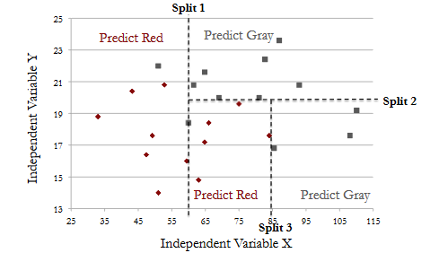

### Final Tree

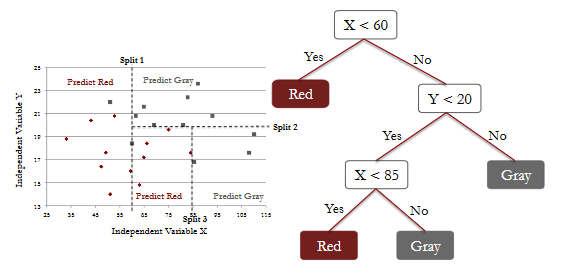

### When Does CART Stop Splitting?

- There are different ways to control how many splits are generated
  - One way is by setting a lower bound for the number of points in each subset
- In R, a parameter that control this is minibucket
  - The smaller it is, the more splits will be generated
  - If it is too small, overfitting will occur
  - If it is too large, model will be too simple and accuracy will be poor

### ROC curve for CART

- Vary the threshold to obtain an ROC curve

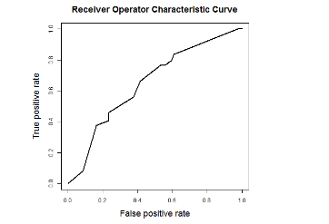

### Random Forests

- Designed to improve prediction accuracy of CART
- Works by building a large number of CART trees
  - Makes model less interpret able
- To make a prediction for a new observation, each tree “votes” on the outcome, and we pick the outcome that receives the majority of the votes

### Building Many Trees

- Each tree can split on only a random subset of the variables
- Each tree is built from a “bagged” /“bootstrapped” sample of the data
  - Select observations randomly with replacement
  - Example - original data: 1 2 3 4 5
  - New “data”:

  2 4 5 2 1 -> 1<sup>st</sup> tree

  3 5 1 5 2 -> 2<sup>nd</sup> tree

### Random Forest Parameters

- Minimum number of observations in a subset
  - In R, this is controlled by the moderate parameter
  - Smaller nodesize may take longer in R
- Number of trees
  - In R, this is the ntree parameter
  - Should not be too small, because bagging procedure may missing observations
  - More tree take longer to build

### Parameter Selection

- In CART, the value of “minibucket” can affect the model’s out-of-sample accuracy
- How should we set this parameter?
- We could select the value that gives the best testing set accuracy
  - This is not right!

### K-fold Cross-Validation

- Given training set, split into k pieces
- Use k-1 folds to estimate a model and test model on remaining on fold (“validation set”) for each candidate parameter value
- Repeat for each of the k folds

### Output of k-fold Cross-Validation

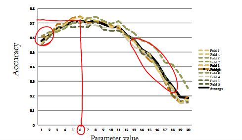

### Cross-Validation in R

- Before, we limited our tree using minibucket
- When we use cross-validation in R, we’ll use a parameter called cp instead
  - Complexity Parameter
- Like Adjusted R<sup>2</sup> and AIC
  - Measures trade-off between model complexity and accuracy on the training set
- Smaller cp leads to a bigger tree (might overfit)

### Martins Model

- Used 628 previous SCOTUS cases between 1994 and 2001
- Made predictions for the 68 cases that would be decided in October 2002, before the term started
- Two stage approach based on CART:
  - First stage: one tree to predict a unanimous liberal decision, other tree to predict unanimous conservative decision.
    - If conflicting predictions or predict no, move to next stage
  - Second stage: predict decisions of each individual justice, and using majority decision as prediction

### Example Trees of Justices

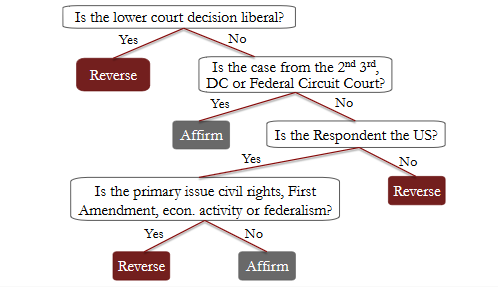

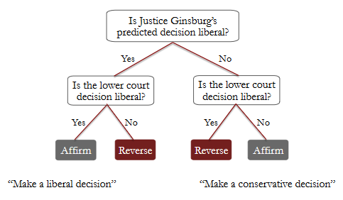

### The Experts

- Martin and his colleagues recruited 83 legal experts
  - 71 academics and 12 attorneys
  - 38 previously clerked for a Supreme Court justice, 33 were chaired professors and 5 were current or former law school deans
- Experts only asked to predict within their area of expertise; more than one expert to each case
- Allowed to consider any source of information, but not allowed to communicate with each other regarding predictions

### The Results

- For the 68 cases in October 2002:
- Overall case predictions:
  - Model accuracy: 75%
  - Experts accuracy: 59%
- Individual justice predictions:
  - Model accuracy: 67%
  - Experts accuracy: 68%

### The Analytics Edge

- Predicting Supreme Court decisions is very valuable to firms, politicians and non-governmental organizations
- A model that predicts these decisions is both more accurate and faster than experts
  - CART model based on very high-level details of case beats experts who can process much more detailed and complex information

## Judge, Jury, and Classifier in R

### Read in the data

```r
# Read in the data
stevens = read.csv("stevens.csv")
# Output structure
str(stevens)
```

```
## 'data.frame':    566 obs. of  9 variables:
##  $ Docket    : Factor w/ 566 levels "00-1011","00-1045",..: 63 69 70 145 97 181 242 289 334 436 ...
##  $ Term      : int  1994 1994 1994 1994 1995 1995 1996 1997 1997 1999 ...
##  $ Circuit   : Factor w/ 13 levels "10th","11th",..: 4 11 7 3 9 11 13 11 12 2 ...
##  $ Issue     : Factor w/ 11 levels "Attorneys","CivilRights",..: 5 5 5 5 9 5 5 5 5 3 ...
##  $ Petitioner: Factor w/ 12 levels "AMERICAN.INDIAN",..: 2 2 2 2 2 2 2 2 2 2 ...
##  $ Respondent: Factor w/ 12 levels "AMERICAN.INDIAN",..: 2 2 2 2 2 2 2 2 2 2 ...
##  $ LowerCourt: Factor w/ 2 levels "conser","liberal": 2 2 2 1 1 1 1 1 1 1 ...
##  $ Unconst   : int  0 0 0 0 0 1 0 1 0 0 ...
##  $ Reverse   : int  1 1 1 1 1 0 1 1 1 1 ...
```

### Split the data

```r
# Split the data
library(caTools)
set.seed(3000)
spl = sample.split(stevens$Reverse, SplitRatio = 0.7)
Train = subset(stevens, spl==TRUE)
Test = subset(stevens, spl==FALSE)
```

### Load CART tree packages

```r
# Load CART tree packages
library(rpart)
library(rpart.plot)
```

### Implement CART Model

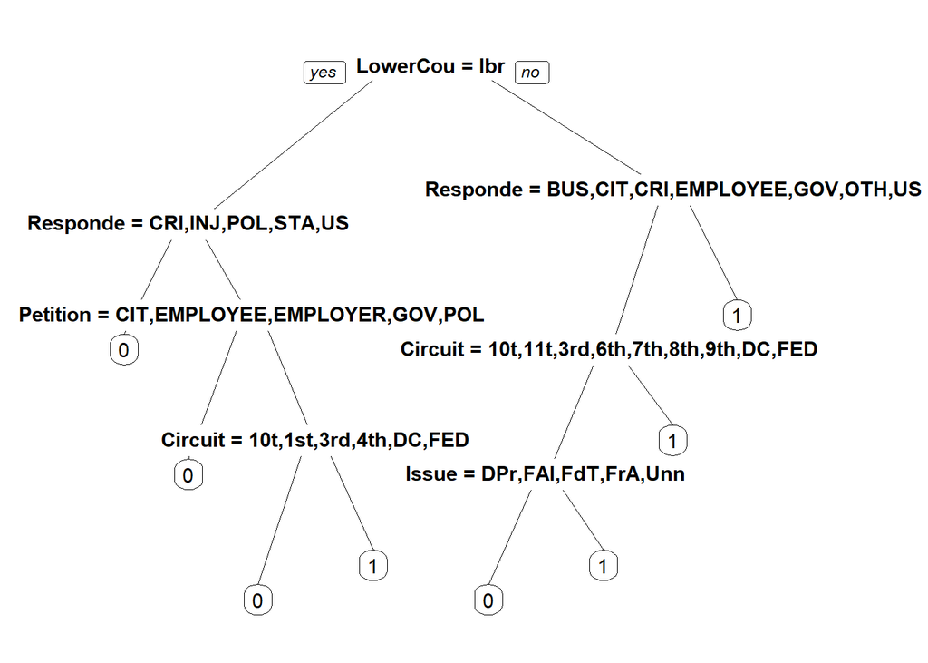

```r
# CART model
StevensTree = rpart(Reverse ~ Circuit + Issue + Petitioner + Respondent + LowerCourt + Unconst, data = Train, method="class", minbucket=25)
# Plot CART tree
prp(StevensTree)
```

### Make predictions

```r
# Make predictions
PredictCART = predict(StevensTree, newdata = Test, type = "class")
z = table(Test$Reverse, PredictCART)
kable(z)
```

|  | 0 | 1 |
| --- | --- | --- |
| 0 | 41 | 36 |
| 1 | 22 | 71 |

```r
# Compute Accuracy
sum(diag(z))/sum(z)
```

```
## [1] 0.6588235
```